# Reproducible Research: Peer Assessment 2

# Weather events most harmful to population health and economic damage in the United States, 1997 to 2011

## Synopsis

The three major causes of weather-related mortality and morbidity in the United States are **excessive heat** (18.0%), **tornados** (15.2%) and **flash flooding** (8.1%). Similar events are also among the three major causes of storm-related injuries (**tornados** 33.0%, **flood** 11.2% and **excessive heat** 10.5%).

Total weather-related fatalities are approximately 650 deaths annually. There are approximately 4025 storm-related injuries annually.

The three weather-related events causing the most economic damage are **flood** (34.3%), **hurricanes** (21.2%) and **storm surges** (15.0%). Total annual economic damage totals approximately $28.7 billion per year.

Crop damage, which is a subset of total economic damage, is also significantly affected by **drought**, which causes about 36% of the total $2.4 billion of weather-related crop damage occurring annually.

Data sourced from NOAA (National Weather Service), 1950-2011.

## Data Processing

```r
### start necessary libraries
library(tidyverse)
library(dplyr)
library(lubridate)
library(rlist)
library(gdata)
library(ggplot2)
library(knitr)

### set figure save path to figure/
knitr::opts_chunk$set(fig.path = 'figure/')
knitr::opts_chunk$set(fig.width=12, fig.height=8)
```

### Download data

Storm Data is from the National Weather Service.

Documentation for the data can be found at the [National Weather Service](https://d396qusza40orc.cloudfront.net/repdata%2Fpeer2_doc%2Fpd01016005curr.pdf) and [National Climatic Data Center Storm Events FAQ](https://d396qusza40orc.cloudfront.net/repdata%2Fpeer2_doc%2FNCDC%20Storm%20Events-FAQ%20Page.pdf)

Data comes in the form of a comma-separated-value file compressed via the bzip2 algorithm.

```r
### download data ZIP file if necessary, and extract if necessary
if (!file.exists('StormData.csv.bz2')) {
  if (download.file('https://d396qusza40orc.cloudfront.net/repdata%2Fdata%2FStormData.csv.bz2','StormData.csv.bz2')) {
    stop('Unable to download data file')
  }
}

StormData <- as.tibble(read.csv(bzfile('StormData.csv.bz2')))
```

Variables of interest

| Variable | Description |
| --- | --- |
| BGN_DATE | date of event starting |
| BGN_TIME | time of event starting |
| TIME_ZONE | time zone of event |
| COUNTYNAME | name of county |
| STATE | state of the United States |
| EVTYPE | type of event |
| FATALITIES | number of fatalities |
| INJURIES | number of injuries |
| PROPDMG | value of property damage in dollars |
| PROPDMGEXP | property damage dollar multiplier (K thousands, M millions, B billions) |
| CROPDMG | value of crop damage in dollars |
| CROPDMGEXP | crop damage dollar multiplier (K thousands, M millions, B billions) |
| REFNUM | unique reference number for event |

### Extract times of storm commencement

Extract time information from **BGN_DATE**, **BGN_TIME** and **TIME_ZONE**, and store in **BEGIN_TIME**.

```r
### Information in BGN_TIME is not consistently stored
### some are in four-digit format e.g. '0000', '1300', '2350'. there is even one three-digit '000'
### others are in 11-character format e.g. '03:25:00 PM'
### convert all to 11-character format

StormData$BGN_calcTIME <- ifelse(str_length(StormData$BGN_TIME)<=4,
                             strftime(strptime(StormData$BGN_TIME,'%H%M'),'%I:%M:%S %p'),
                             as.character(StormData$BGN_TIME))
### more times which are in 'invalid' AM/PM format
### e.g. 15:30:00 PM, or 00:00:10 AM
### re-interpret these as 24-hour times
invalid.time.list <- is.na(strptime(StormData$BGN_calcTIME,'%I:%M:%S %p'))
StormData$BGN_calcTIME[invalid.time.list] <-
  strftime(strptime(StormData[invalid.time.list,]$BGN_calcTIME,'%H:%M'), '%I:%M:%S %p')

### some times still remain invalid
kable(StormData[is.na(StormData$BGN_calcTIME),c('BGN_TIME','COUNTYNAME','STATE','REFNUM')],
      title = 'Invalid times to be manually adjusted')
```

| BGN_TIME | COUNTYNAME | STATE | REFNUM |
| --- | --- | --- | --- |
| 1990 | SCREVEN | GA | 197399 |
| 9999 | OHZ060 - 070>078 | OH | 223421 |
| 2090 | FAIRFAX | VA | 244548 |
| 1580 | KENOSHA | WI | 247251 |
| 0572 | WASHINGTON | WI | 247767 |
| 13O0 | PRZ001 | PR | 248507 |

```r
### these times are 'impossible' e.g. 19:90 hr, or sometimes subsituted a '0 (zero)' for 'O (letter)'
### manually adjust these times, assuming simple transposition or substitution errors
StormData$BGN_calcTIME[StormData$REFNUM == 197399] <- '07:09:00 PM' ### was 1990
StormData$BGN_calcTIME[StormData$REFNUM == 223421] <- '12:01:00 AM' ### was 9999
StormData$BGN_calcTIME[StormData$REFNUM == 244548] <- '08:09:00 PM' ### was 2090
StormData$BGN_calcTIME[StormData$REFNUM == 247251] <- '03:08:00 PM' ### was 1580
StormData$BGN_calcTIME[StormData$REFNUM == 247767] <- '05:27:00 AM' ### was 0572
StormData$BGN_calcTIME[StormData$REFNUM == 248507] <- '01:00:00 PM' ### was 13O0

StormData$BEGIN_TIME <- as.POSIXct(strptime(paste(sub(' .*','',StormData$BGN_DATE),
                                       StormData$BGN_calcTIME),'%m/%d/%Y %I:%M:%S %p'))
```

#### **TIME_ZONE** information, in particular, requires tidying up and adjustment.

List all current timezones, and standardize capitalization

```r
kable(unique(StormData$TIME_ZONE))
```

| x |
| --- |
| CST |
| EST |
| PST |
| MST |
| CDT |
| PDT |
| EDT |
| UNK |
| HST |
| GMT |
| MDT |
| AST |
| ADT |
| CSt |
| ESt |
| CSC |
| SCT |
| ESY |
| UTC |
| SST |
| AKS |
| GST |

```r
### some timezone names use 'lower-case' characters, convert all to upper-case
StormData$TIME_ZONE <- as.factor(toupper(StormData$TIME_ZONE))
```

```r
kable(StormData[StormData$TIME_ZONE %in% c('UNK','CSC','ESY','SCT'), c('COUNTYNAME','STATE','TIME_ZONE','REFNUM')],
      title = 'List of records with dubious timezone names')
```

| COUNTYNAME | STATE | TIME_ZONE | REFNUM |
| --- | --- | --- | --- |
| OCONEE | GA | UNK | 23087 |
| HAWAII | HI | UNK | 27702 |
| COLES | IL | UNK | 30669 |
| RUSH | IN | UNK | 35244 |
| HAMPDEN | MA | UNK | 67899 |
| LOVE | OK | UNK | 120704 |
| PERKINS | SD | UNK | 143198 |
| MCLENNAN | TX | UNK | 154637 |
| ARMSTRONG | TX | UNK | 160236 |
| CHICKASAW | IA | CSC | 200720 |
| IAZ033 - 034 - 045>052 - 057>068 - 070>078 - 081>089 - 092>099 | IA | SCT | 201257 |
| CAMBRIA | PA | ESY | 229824 |
| SHAWANO | WI | SCT | 247612 |

#### Correct/adjust timezones.

Convert ‘daylight saving’ timezones to ‘standard’ timezones, as Lubridate adjusts for daylight saving times automatically.

```r
### replace missing timezones 'UNK'
### Oconee County, Georgia
StormData$TIME_ZONE[StormData$REFNUM == 23087] <- 'EST'
### Hawaii country, Hawaii
StormData$TIME_ZONE[StormData$REFNUM == 27702] <- 'HST'
### Coles county, Illinois
StormData$TIME_ZONE[StormData$REFNUM == 30669] <- 'CST'
### Rush County, Indiana
StormData$TIME_ZONE[StormData$REFNUM == 35244] <- 'EST'
### Hampden County, Massachusetts
StormData$TIME_ZONE[StormData$REFNUM == 67899] <- 'EST'
### Love County, Oklahoma
StormData$TIME_ZONE[StormData$REFNUM == 120704] <- 'CST'
### Perkins County, South Dakota
StormData$TIME_ZONE[StormData$REFNUM == 143198] <- 'MST'
### McLennan County, Texas
StormData$TIME_ZONE[StormData$REFNUM == 154637] <- 'CST'
### Armstrong, Texas
StormData$TIME_ZONE[StormData$REFNUM == 160236] <- 'CST'

### Chickasaw, Mississippi. likely mistaken timezone 'CSC'
StormData$TIME_ZONE[StormData$REFNUM == 200720] <- 'CST'
### Cambria, Pennsylvania, likely mistaken timezone 'ESY'
StormData$TIME_ZONE[StormData$REFNUM == 229824] <- 'EST'
### Shawano, Wisconsin, likely mistaken timezone 'SCT'
StormData$TIME_ZONE[StormData$REFNUM == 247612] <- 'CST'
### IAZ033, Indiana, likely mistaken timezone 'SCT'
StormData$TIME_ZONE[StormData$REFNUM == 201257] <- 'EST'

### convert daylight saving timezones to 'standard' time
StormData$TIME_ZONE[StormData$TIME_ZONE == 'ADT'] <- 'AST'
StormData$TIME_ZONE[StormData$TIME_ZONE == 'CDT'] <- 'CST'
StormData$TIME_ZONE[StormData$TIME_ZONE == 'EDT'] <- 'EST'
StormData$TIME_ZONE[StormData$TIME_ZONE == 'MDT'] <- 'MST'
StormData$TIME_ZONE[StormData$TIME_ZONE == 'PDT'] <- 'PST'
```

Adjust **BEGIN_TIME** according to **TIME_ZONE**.

```r
### adjust time zones. roll=TRUE prevents 'NA' times as result of daylight savings
StormData[StormData$TIME_ZONE == 'AKS',]$BEGIN_TIME <-
  force_tz(StormData[StormData$TIME_ZONE == 'AKS',]$BEGIN_TIME, tzone = 'America/Anchorage', roll = TRUE)
StormData[StormData$TIME_ZONE == 'AST',]$BEGIN_TIME <-
  force_tz(StormData[StormData$TIME_ZONE == 'AST',]$BEGIN_TIME, tzone = 'America/Halifax', roll = TRUE)
StormData[StormData$TIME_ZONE == 'CST',]$BEGIN_TIME <-
  force_tz(StormData[StormData$TIME_ZONE == 'CST',]$BEGIN_TIME, tzone = 'America/Chicago', roll = TRUE)
StormData[StormData$TIME_ZONE == 'EST',]$BEGIN_TIME <-
  force_tz(StormData[StormData$TIME_ZONE == 'EST',]$BEGIN_TIME, tzone = 'America/New_York', roll = TRUE)
StormData[StormData$TIME_ZONE == 'HST',]$BEGIN_TIME <-
  force_tz(StormData[StormData$TIME_ZONE == 'HST',]$BEGIN_TIME, tzone = 'Pacific/Honolulu', roll = TRUE)
StormData[StormData$TIME_ZONE == 'MST',]$BEGIN_TIME <-
  force_tz(StormData[StormData$TIME_ZONE == 'MST',]$BEGIN_TIME, tzone = 'America/Denver', roll = TRUE)
StormData[StormData$TIME_ZONE == 'PST',]$BEGIN_TIME <-
  force_tz(StormData[StormData$TIME_ZONE == 'PST',]$BEGIN_TIME, tzone = 'America/Los_Angeles', roll = TRUE)
StormData[StormData$TIME_ZONE == 'SST',]$BEGIN_TIME <-
  force_tz(StormData[StormData$TIME_ZONE == 'SST',]$BEGIN_TIME, tzone = 'Pacific/Samoa', roll = TRUE)
### other timezones 'GMT', 'GST', and 'UTC' all appear to be UTC+0, and so left alone
```

### Event synonyms

Some events in **EVTYPE** which appear to be the same are recorded with different names (synonyms)

e.g. ‘TSTM WIND’, ‘THUNDERSTORM WIND’, ‘THUNDERSTORM WINDS’

These synonyms should be merged.

In this section ‘close’ synonyms will not be merged e.g. ‘MARINE THUNDERSTORM WIND’ will not be merged with ‘THUNDERSTORM WIND’, ‘THUNDERSTORM WIND/HAIL’ will not be merged into ‘THUNDERSTORM WIND’ and ‘STRONG WIND’ will not be merged into ‘WIND’, although arguably some of these close synonyms are the same.

```r
### Most events are recorded in capitals ('upper case'), but some are recorded in mixed (upper and lower) case
### Covert all to upper case, strip all numbers, periods and trailing/leading whitespace
### numbers and parentheses are often used to describe sub-types within an event type e.g. size of hail
### there are some subtypes which are not yet merged with this logic e.g. 'G45' sub-types
StormData$EVTYPE <- as.factor(toupper(trimws(gsub('[0-9,.,(,)]+','',StormData$EVTYPE))))

### list of synonyms
synonyms <- list(c('THUNDERSTORM WIND','TSTM WIND','THUNDERSTORM WINDS','THUNDERSTORM WINDSS','THUNDERSTORMS WINDS','THUNDERSTROM WIND','THUNDERTSORM WIND','THUNERSTORM WINDS','TUNDERSTORM WIND','THUNDERSTORM WINS','TSTM WND'),
                 c('MARINE THUNDERSTORM WIND','MARINE TSTM WIND','MARINE TSTM WINDS'),
                 c('HIGH WIND','STRONG WIND','HIGH WINDS','STRONG WINDS'),
                 c('FLASH FLOOD','FLASH FLOODING','FLASH FLOODS'),
                 c('FLOOD','FLOODING'),
                 c('URBAN FLOOD','URBAN FLOODING'),
                 c('WILDFIRE','WILD/FOREST FIRE'),
                 c('RECORD HEAT','RECORD WARMTH'),
                 c('THUNDERSTORM WINDS HAIL','TSTM WIND/HAIL','THUNDERSTORM WINDS/HAIL'),
                 c('WIND GUSTS','GUSTY WIND'),
                 c('TORRENTIAL RAIN','TORRENTIAL RAINFALL'),
                 c('TORNADO','TORNADOS','TORNDAO'),
                 c('WIND','WND'),
                 c('THUNDERSTORM','THUNDERSTORMS'),
                 c('RIP CURRENT', 'RIP CURRENTS'),
                 c('HURRICANE','TYPHOON','HURRICANE/TYPHOON'))

### merge synonyms into one synonym
for (events in synonyms) {
  StormData[as.character(StormData$EVTYPE) %in% events,]$EVTYPE <- events[1]
}
```

### Economic damage value calculations

Calculate ‘true’ dollar values of economic damage, combining **PROPDMG** with **PROPDMGEXP** and **CROPDMG** and **CROPDMGEXP**

In [National Weather Service](https://d396qusza40orc.cloudfront.net/repdata%2Fpeer2_doc%2Fpd01016005curr.pdf) there are only three recognized abbreviations for **PROPDMGEXP** and **CROPDMGEXP**, being ‘K’ for thousands, ‘M’ for millions and ‘B’ for billions.

```r
### convert the property and crop damage variables to true numeric values
StormData <- StormData %>%
  mutate(PropertyValue = PROPDMG * 1000^match(toupper(PROPDMGEXP),c('K','M','B'), nomatch=0)) %>%
  mutate(CropValue = CROPDMG * 1000^match(toupper(CROPDMGEXP),c('K','M','B'), nomatch=0))
```

### Finding data which appears to have been collected consistently with the most recent years

```r
### find the most common event types
frequent.events <- StormData %>%
  count(EVTYPE) %>%
  arrange(desc(n))

# show the twenty most frequent event types
print(head(frequent.events,20))
```

```
## # A tibble: 20 x 2
##    EVTYPE                        n
##    <fct>                     <int>
##  1 THUNDERSTORM WIND        323458
##  2 HAIL                     288761
##  3 TORNADO                   60654
##  4 FLASH FLOOD               54992
##  5 HIGH WIND                 25536
##  6 FLOOD                     25447
##  7 LIGHTNING                 15756
##  8 HEAVY SNOW                15708
##  9 MARINE THUNDERSTORM WIND  11987
## 10 HEAVY RAIN                11742
## 11 WINTER STORM              11433
## 12 WINTER WEATHER             7045
## 13 FUNNEL CLOUD               6845
## 14 WILDFIRE                   4218
## 15 WATERSPOUT                 3797
## 16 URBAN/SML STREAM FLD       3392
## 17 BLIZZARD                   2719
## 18 DROUGHT                    2488
## 19 ICE STORM                  2006
## 20 EXCESSIVE HEAT             1678
```

Plot the yearly event count for the top ten events, and the total event count (the total event count includes both ‘common’ and ‘uncommon’ events)

In order to make comparison easier, the event counts are ‘normalized’ to the 2011 counts i.e. the 2011 counts are the ‘baseline’.

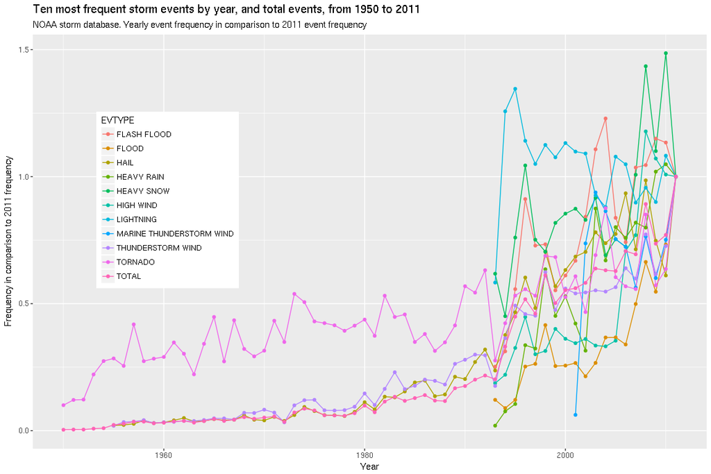

```r
# the ten most frequent events
most.frequent.events <- as.list(as.character(frequent.events[1:10,]$EVTYPE))

# count the events in 'most.frequent.events' in each year of recording
frequent.event.count <- StormData %>%
  filter(EVTYPE %in% most.frequent.events) %>%
  mutate(event.year = year(BEGIN_TIME)) %>%
  group_by(event.year, EVTYPE) %>%
  summarise(events = n())

# and the total events for each year
yearly.event.count <- StormData %>%
  mutate(event.year = year(BEGIN_TIME)) %>%
  group_by(event.year) %>%
  summarise(events = n())

yearly.event.count[,'EVTYPE'] <- 'TOTAL'

event.count <- bind_rows(frequent.event.count,yearly.event.count)

# 'normalize the events' to the frequency observed in 2011
# store the normalized event count in 'event.norm'
event.count[,'event.norm'] <- NA

for (event in list.append(most.frequent.events,'TOTAL')) {
  event.2011.count <- with(event.count, events[EVTYPE == event & event.year == 2011])
  for (year in with(event.count, event.year[EVTYPE == event])) {
    index <- with(event.count,(EVTYPE == event) & (event.year == year))
    event.count$event.norm[index] <- (event.count$events[index]/event.2011.count)
  }
}

ggplot(data=event.count,aes(x=event.year,y=event.norm,group=EVTYPE, colour=EVTYPE)) +
  geom_line()+geom_point() +
  labs(title = "Ten most frequent storm events by year, and total events, from 1950 to 2011",
       subtitle = "NOAA storm database. Yearly event frequency in comparison to 2011 event frequency") +
  labs(x = "Year", y = "Frequency in comparison to 2011 frequency") +
  guides(fill = guide_legend(title="")) +
  theme(legend.position=c(0.2,0.6))
```

Many of the frequent events are not recorded in the current form until at the mid-1990s. ‘MARINE THUNDERSTORM WIND’ is not even recorded until 2001.

Restrict data analysis from 1997 to 2011 (fifteen years in total)

```r
StormSubset <- StormData[year(StormData$BEGIN_TIME)>=1997,
                         c('COUNTYNAME','STATE','EVTYPE','FATALITIES','INJURIES',
                           'PROPDMG','PROPDMGEXP','CROPDMG','CROPDMGEXP',
                           'REFNUM','PropertyValue','CropValue','BEGIN_TIME')]
```

## Results

### Which types of events are most harmful with respect to population health?

Rank the twenty events with the greatest number of fatalities or injuries per year. Population health harm contained in variables **FATALITIES** and **INJURIES**.

```r
### calculate the sum of fatalities and injuries for each event for each year
HealthSum <- StormSubset %>%
  mutate(event.year = year(BEGIN_TIME)) %>%
  group_by(event.year, EVTYPE) %>%
  summarise(fatalities = sum(FATALITIES), injuries = sum(INJURIES))

### calculate the mean ('average') annual fatalities and injuries for each event
### calculate the proportion of annual fatalities or injuries caused by the event
HealthMean <- HealthSum %>%
  group_by(EVTYPE) %>%
  summarise(mean_fatalities = mean(fatalities), mean_injuries = mean(injuries)) %>%
  mutate(proportion_fatalities = mean_fatalities/sum(mean_fatalities)*100) %>%
  mutate(proportion_injuries = mean_injuries/sum(mean_injuries)*100) %>%
  arrange(desc(mean_fatalities))

kable(HealthMean[1:20,c('EVTYPE','mean_fatalities','proportion_fatalities')], caption = 'Weather events causing most fatalities, annual mean fatalities, and percentage of fatalities caused by event')
```

Weather events causing most fatalities, annual mean fatalities, and percentage of fatalities caused by event

| EVTYPE | mean_fatalities | proportion_fatalities |
| --- | --- | --- |
| EXCESSIVE HEAT | 117.400000 | 17.968625 |
| TORNADO | 99.000000 | 15.152418 |
| FLASH FLOOD | 53.000000 | 8.111901 |
| LIGHTNING | 39.866667 | 6.101782 |
| RIP CURRENT | 34.466667 | 5.275286 |
| FLOOD | 25.466667 | 3.897794 |
| HEAT | 23.700000 | 3.627397 |
| THUNDERSTORM WIND | 23.266667 | 3.561073 |
| HIGH WIND | 21.000000 | 3.214149 |
| AVALANCHE | 14.533333 | 2.224395 |
| COLD AND SNOW | 14.000000 | 2.142766 |
| COLD/WIND CHILL | 13.571429 | 2.077171 |
| EXTREME COLD/WIND CHILL | 12.500000 | 1.913184 |
| WINTER STORM | 11.133333 | 1.704009 |
| HEAVY SURF/HIGH SURF | 10.500000 | 1.607075 |
| EXTREME COLD | 9.285714 | 1.421223 |
| FOG | 8.285714 | 1.268168 |
| TSUNAMI | 8.250000 | 1.262701 |
| HYPOTHERMIA/EXPOSURE | 7.000000 | 1.071383 |
| HIGH SURF | 6.692308 | 1.024289 |

```r
total_mean_fatalities <- sum(HealthMean$mean_fatalities)
sprintf('Total mean number of fatalities annually: %.1f',total_mean_fatalities)
```

```
## [1] "Total mean number of fatalities annually: 653.4"
```

```r
kable(arrange(HealthMean,desc(mean_injuries))[1:20,c('EVTYPE','mean_injuries','proportion_injuries')],caption = 'Weather events causing the most injuries, annual mean injuries and percentage of injuries caused by event')
```

Weather events causing the most injuries, annual mean injuries and percentage of injuries caused by event

| EVTYPE | mean_injuries | proportion_injuries |
| --- | --- | --- |
| TORNADO | 1330.80000 | 33.0652423 |
| FLOOD | 449.33333 | 11.1641986 |
| EXCESSIVE HEAT | 422.13333 | 10.4883836 |
| THUNDERSTORM WIND | 313.66667 | 7.7934057 |
| LIGHTNING | 255.06667 | 6.3374219 |
| HEAT | 122.20000 | 3.0361982 |
| FLASH FLOOD | 108.66667 | 2.6999471 |
| FOG | 95.71429 | 2.3781305 |
| WILDFIRE | 94.86667 | 2.3570704 |
| HURRICANE | 93.50000 | 2.3231140 |
| HIGH WIND | 84.60000 | 2.1019834 |
| WINTER STORM | 69.46667 | 1.7259785 |
| GLAZE | 53.00000 | 1.3168454 |
| HAIL | 42.06667 | 1.0451943 |
| HEAVY SNOW | 37.86667 | 0.9408405 |
| WINTER WEATHER MIX | 34.00000 | 0.8447687 |
| TSUNAMI | 32.25000 | 0.8012880 |
| RIP CURRENT | 29.20000 | 0.7255073 |
| WINTER WEATHER | 26.38462 | 0.6555558 |
| MIXED PRECIP | 26.00000 | 0.6459996 |

```r
total_mean_injuries <- sum(HealthMean$mean_injuries)
sprintf('Total mean number of injuries annually: %.1f',total_mean_injuries)
```

```
## [1] "Total mean number of injuries annually: 4024.8"
```

Display results graphically of the events causing the most fatalities and injuries

```r
### the (union) of the ten events causing the most fatalities and ten events causing the most injuries
most_health_events <- union(HealthMean$EVTYPE[1:10],arrange(HealthMean,desc(mean_injuries))$EVTYPE[1:10])

### gather data in preparation for bar-charting
HealthImpact <- HealthMean %>%
  filter(HealthMean$EVTYPE %in% most_health_events) %>%
  mutate(Injuries = -proportion_injuries) %>% ### negative values will be used for 'bar-negative-stack' later
  rename(Fatalities = proportion_fatalities) %>%
  select(one_of('EVTYPE','Injuries','Fatalities')) %>%
  gather(key = 'harm', value = 'proportion', Injuries, Fatalities)

# arrange factors by fatality order
HealthImpact$EVTYPE = reorder.factor(HealthImpact$EVTYPE, new.order = arrange(HealthMean,mean_fatalities)$EVTYPE)
arrange(HealthImpact, EVTYPE)
```

```
## # A tibble: 26 x 3
##    EVTYPE    harm       proportion
##    <fct>     <chr>           <dbl>
##  1 WILDFIRE  Injuries       -2.36
##  2 WILDFIRE  Fatalities      0.888
##  3 HURRICANE Injuries       -2.32
##  4 HURRICANE Fatalities      0.973
##  5 FOG       Injuries       -2.38
##  6 FOG       Fatalities      1.27
##  7 AVALANCHE Injuries       -0.250
##  8 AVALANCHE Fatalities      2.22
##  9 HIGH WIND Injuries       -2.10
## 10 HIGH WIND Fatalities      3.21
## # ... with 16 more rows
```

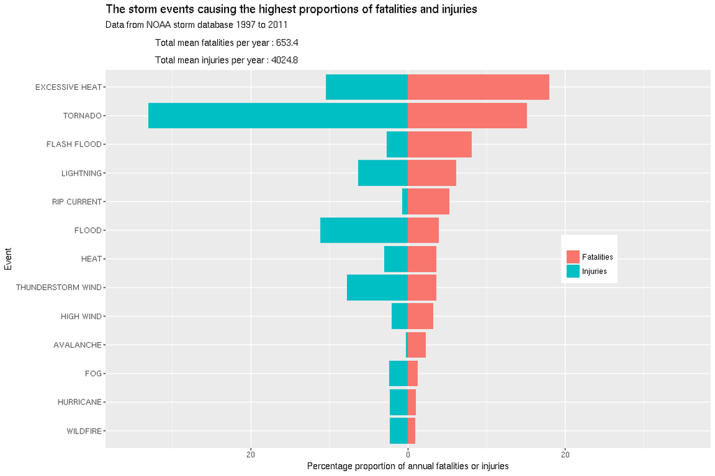

```r
subtitle <- sprintf('Data from NOAA storm database 1997 to 2011\n
                    Total mean fatalities per year : %.1f\n
                    Total mean injuries per year : %.1f',
                    total_mean_fatalities, total_mean_injuries)

ggplot(data=HealthImpact, aes(x = EVTYPE, y = proportion, fill = harm)) +
  geom_bar(stat = 'identity') + ### 'identity' needed for values (rather than counts)
  labs(title = "The storm events causing the highest proportions of fatalities and injuries",
       subtitle = subtitle) +
  labs(x = "Event", y = "Percentage proportion of annual fatalities or injuries") +
  scale_y_continuous(labels=abs) +
                     ### remove negative values for axis for 'negative' part of chart
  guides(fill = guide_legend(title="")) +
  theme(legend.position=c(0.8,0.5)) +
  coord_flip(ylim=c(-35,35))
```

### Which types of events have the greatest economic consequences?

Rank the twenty events with the greatest value of property or crop damage per year Economic damage information is stored in **PropertyValue** and **CropValue**.

```r
### remove variables no longer required
DamageSubset <- StormSubset %>%
  select(-c(PROPDMG,PROPDMGEXP,CROPDMG,CROPDMGEXP,FATALITIES,INJURIES))

### calculate the sum of damage for each event for each year
DamageSum <- DamageSubset %>%
  mutate(event.year = year(BEGIN_TIME)) %>%
  group_by(event.year, EVTYPE) %>%
  summarise(property = sum(PropertyValue), crop = sum(CropValue))

### calculate the mean ('average') damage for each event (for each of property and crop)
### calculate the proportion of annual damage caused by event (for each of property and crop)
### and also calculate combined mean damage (property+crop) and proportion
DamageMean <- DamageSum %>%
  group_by(EVTYPE) %>%
  summarise(mean_property = mean(property), mean_crop = mean(crop)) %>%
  mutate(mean_combined = mean_property + mean_crop) %>%
  mutate(proportion_property = mean_property/sum(mean_property)*100) %>%
  mutate(proportion_crop = mean_crop/sum(mean_crop)*100) %>%
  mutate(proportion_combined = mean_combined/sum(mean_combined)*100) %>%
  arrange(desc(mean_property))

kable(DamageMean[1:20,c('EVTYPE','mean_property','proportion_property')], caption = 'Weather events causing most property damage, annual mean property damage, and percentage of property damage caused by event')
```

Weather events causing most property damage, annual mean property damage, and percentage of property damage caused by event

| EVTYPE | mean_property | proportion_property |
| --- | --- | --- |
| FLOOD | 9531642097 | 36.2058371 |
| HURRICANE | 5738335644 | 21.7970045 |
| STORM SURGE | 4318594900 | 16.4041350 |
| TORNADO | 1593155877 | 6.0515850 |
| FLASH FLOOD | 945352367 | 3.5909105 |
| HAIL | 932133795 | 3.5406999 |
| STORM SURGE/TIDE | 663026857 | 2.5185002 |
| WILDFIRE | 512436633 | 1.9464849 |
| TROPICAL STORM | 506411703 | 1.9235993 |
| THUNDERSTORM WIND | 497588195 | 1.8900833 |
| HIGH WIND | 354029326 | 1.3447765 |
| ICE STORM | 236839987 | 0.8996341 |
| WINTER STORM | 99690550 | 0.3786735 |
| DROUGHT | 60713400 | 0.2306192 |
| LIGHTNING | 47244955 | 0.1794594 |
| HEAVY RAIN | 36684229 | 0.1393446 |
| TSUNAMI | 36015500 | 0.1368045 |
| HEAVY SNOW | 33396323 | 0.1268556 |
| BLIZZARD | 32326930 | 0.1227935 |
| LANDSLIDE | 29507091 | 0.1120824 |

```r
total_mean_property <- sum(DamageMean$mean_property)
sprintf('Total mean value of property damage annually: $%.0f',total_mean_property)
```

```
## [1] "Total mean value of property damage annually: $26326258003"
```

```r
kable(arrange(DamageMean,desc(mean_crop))[1:20,c('EVTYPE','mean_crop','proportion_crop')],caption = 'Weather events causing the most crop damage, annual mean crop damage and percentage of crop damage caused by event')
```

Weather events causing the most crop damage, annual mean crop damage and percentage of crop damage caused by event

| EVTYPE | mean_crop | proportion_crop |
| --- | --- | --- |
| DROUGHT | 857565733 | 35.8547176 |
| HURRICANE | 357161629 | 14.9328837 |
| FLOOD | 310131493 | 12.9665595 |
| EXTREME COLD | 162917714 | 6.8115696 |
| HAIL | 152800840 | 6.3885843 |
| FROST/FREEZE | 99471455 | 4.1588893 |
| FLASH FLOOD | 84755447 | 3.5436148 |
| THUNDERSTORM WIND | 61726533 | 2.5807788 |
| HEAVY RAIN | 48544387 | 2.0296348 |
| TROPICAL STORM | 45114067 | 1.8862136 |
| HIGH WIND | 39428147 | 1.6484860 |
| EXCESSIVE HEAT | 32826800 | 1.3724845 |
| AGRICULTURAL FREEZE | 28820000 | 1.2049606 |
| WILDFIRE | 26612009 | 1.1126448 |
| FREEZE | 24370833 | 1.0189415 |
| TORNADO | 18061054 | 0.7551304 |
| THUNDERSTORM WINDS HAIL | 7164464 | 0.2995454 |
| HARD FREEZE | 6450000 | 0.2696737 |
| UNSEASONAL RAIN | 5000000 | 0.2090494 |
| HEAVY SNOW | 4726807 | 0.1976272 |

```r
total_mean_crop <- sum(DamageMean$mean_crop)
sprintf('Total mean value of crop damage annually: $%.0f',total_mean_crop)
```

```
## [1] "Total mean value of crop damage annually: $2391779355"
```

```r
kable(arrange(DamageMean,desc(mean_combined))[1:20,c('EVTYPE','mean_combined','proportion_combined')],caption = 'Weather events causing the most economic damage, annual mean economic damage and percentage of economic damage caused by event')
```

Weather events causing the most economic damage, annual mean economic damage and percentage of economic damage caused by event

| EVTYPE | mean_combined | proportion_combined |
| --- | --- | --- |
| FLOOD | 9841773590 | 34.2703558 |
| HURRICANE | 6095497272 | 21.2253268 |
| STORM SURGE | 4318594900 | 15.0379180 |
| TORNADO | 1611216931 | 5.6104702 |
| HAIL | 1084934635 | 3.7778857 |
| FLASH FLOOD | 1030107814 | 3.5869715 |
| DROUGHT | 918279133 | 3.1975693 |
| STORM SURGE/TIDE | 663148286 | 2.3091699 |
| THUNDERSTORM WIND | 559314729 | 1.9476078 |
| TROPICAL STORM | 551525770 | 1.9204856 |
| WILDFIRE | 539048642 | 1.8770386 |
| HIGH WIND | 393457473 | 1.3700709 |
| ICE STORM | 237503987 | 0.8270203 |
| EXTREME COLD | 163610286 | 0.5697126 |
| FROST/FREEZE | 100424182 | 0.3496903 |
| WINTER STORM | 100243950 | 0.3490627 |
| HEAVY RAIN | 85228616 | 0.2967773 |
| LIGHTNING | 47701395 | 0.1661026 |
| HEAVY SNOW | 38123129 | 0.1327498 |
| TSUNAMI | 36020500 | 0.1254281 |

```r
total_mean_combined <- sum(DamageMean$mean_combined)
sprintf('Total mean economic damage annually: $%.0f',total_mean_combined)
```

```
## [1] "Total mean economic damage annually: $28718037357"
```

Display results graphically of the events causing the most property and crop damage

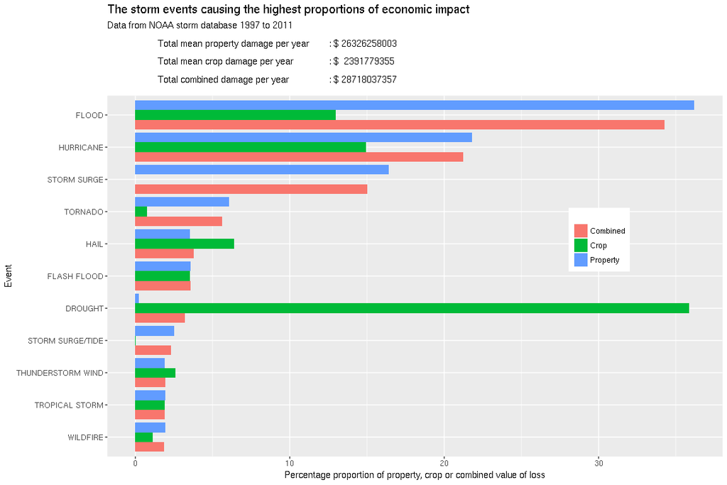

```r
### the (union) of the ten events causing the most property, crop or combined economic damage
most_damage_events <- Reduce(union, list(DamageMean$EVTYPE[1:10],arrange(DamageMean,desc(mean_combined))$EVTYPE[1:10],
                            arrange(DamageMean,desc(mean_combined))$EVTYPE[1:10]))

### gather data in preparation for bar-charting
DamageImpact <- DamageMean %>%
  filter(DamageMean$EVTYPE %in% most_damage_events) %>%
  rename(Property = proportion_property, Crop = proportion_crop, Combined = proportion_combined) %>%
  select(one_of('EVTYPE','Property','Crop','Combined')) %>%
  gather(key = 'damage', value = 'proportion', Property, Crop, Combined)

### order the event types by the 'mean_combined' economic impact
DamageImpact$EVTYPE <- reorder.factor(DamageImpact$EVTYPE, new.order = arrange(DamageMean,mean_combined)$EVTYPE)
DamageImpact <- arrange(DamageImpact,EVTYPE)

subtitle <- sprintf('Data from NOAA storm database 1997 to 2011\n
                    Total mean property damage per year \t: $%12.0f\n
                    Total mean crop damage per year \t\t: $%12.0f\n
                    Total combined damage per year \t\t: $%12.0f\n',
                    total_mean_property, total_mean_crop, total_mean_combined)

ggplot(data=DamageImpact, aes(x = EVTYPE, y = proportion, fill = damage)) +
  geom_bar(stat = 'identity', position = 'dodge') + ### 'identity' needed for values (rather than counts)
  ### 'dodge' for side-by-side bar chart
  labs(title = "The storm events causing the highest proportions of economic impact",
       subtitle = subtitle) +
  labs(x = "Event", y = "Percentage proportion of property, crop or combined value of loss") +
  guides(fill = guide_legend(title="")) +
  theme(legend.position=c(0.8,0.6)) +
  coord_flip()
```